# Week 02: R for Data Analytics

## 4.2 Multiple Linear Regression

```r
# Build multiple regression model
# Predict Petal Length from multiple predictors
model_multiple <- lm(Petal.Length ~ Sepal.Length + Sepal.Width + Petal.Width,
                     data = iris)

# View summary
summary(model_multiple)
```

```
##
## Call:
## lm(formula = Petal.Length ~ Sepal.Length + Sepal.Width + Petal.Width,
##     data = iris)
##
## Residuals:
##      Min       1Q   Median       3Q      Max
## -0.99333 -0.17656 -0.01004  0.18558  1.06909
##
## Coefficients:
##              Estimate Std. Error t value Pr(>|t|)
## (Intercept)  -0.26271    0.29741  -0.883    0.379
## Sepal.Length  0.72914    0.05832  12.502   <2e-16 ***
## Sepal.Width  -0.64601    0.06850  -9.431   <2e-16 ***
## Petal.Width   1.44679    0.06761  21.399   <2e-16 ***
## ---
## Signif. codes:  0 '***' 0.001 '**' 0.01 '*' 0.05 '.' 0.1 ' ' 1
##
## Residual standard error: 0.319 on 146 degrees of freedom
## Multiple R-squared:  0.968,  Adjusted R-squared:  0.9674
## F-statistic:  1473 on 3 and 146 DF,  p-value: < 2.2e-16
```

```r
# Compare models
cat("\n=== MODEL COMPARISON ===\n")
```

```
##
## === MODEL COMPARISON ===
```

```r
comparison <- data.frame(
  Model = c("Simple Regression", "Multiple Regression"),
  Predictors = c(1, 3),
  R_squared = c(
    summary(model_simple)$r.squared,
    summary(model_multiple)$r.squared
  ),
  Adj_R_squared = c(
    summary(model_simple)$adj.r.squared,
    summary(model_multiple)$adj.r.squared
  ),
  RMSE = c(
    sqrt(mean(model_simple$residuals^2)),
    sqrt(mean(model_multiple$residuals^2))
  )
)

comparison %>%
  mutate(across(where(is.numeric), ~round(., 4))) %>%
  kable(caption = "Model Performance Comparison") %>%
  kable_styling(bootstrap_options = c("striped", "hover"))
```

Model Performance Comparison

| Model | Predictors | R_squared | Adj_R_squared | RMSE |
| --- | --- | --- | --- | --- |
| Simple Regression | 1 | 0.0138 | 0.0072 | 0.4314 |
| Multiple Regression | 3 | 0.9680 | 0.9674 | 0.3147 |

## 4.3 Making Predictions

```r
# Create new data for predictions
new_data <- data.frame(
  Sepal.Length = c(5.0, 6.0, 7.0),
  Sepal.Width = c(3.0, 3.5, 3.2),
  Petal.Width = c(1.5, 2.0, 2.5)
)

# Make predictions
predictions <- predict(model_multiple, newdata = new_data, interval = "prediction")

# Combine with input data
prediction_results <- cbind(new_data, predictions) %>%
  mutate(across(where(is.numeric), ~round(., 2)))

prediction_results %>%
  kable(caption = "Predictions with 95% Confidence Intervals") %>%
  kable_styling(bootstrap_options = c("striped", "hover"))
```

| Sepal.Length | Sepal.Width | Petal.Width | fit | lwr | upr |
| --- | --- | --- | --- | --- | --- |
| 5 | 3.0 | 1.5 | 3.62 | 2.97 | 4.26 |
| 6 | 3.5 | 2.0 | 4.74 | 4.10 | 5.39 |
| 7 | 3.2 | 2.5 | 6.39 | 5.75 | 7.03 |

# Part 5: Hypothesis Testing

## 5.1 Understanding Hypotheses

### 5.1.1 What is a Hypothesis?

A **hypothesis** is a prediction from a theory that can be tested through data collection and analysis. It’s a specific, testable statement about the relationship between variables.

**Key Characteristics of a Good Hypothesis:**

1. **Clear and understandable** - Anyone should be able to understand what you’re predicting
2. **Testable** - You must be able to collect data to test it
3. **Measurable** - The variables must be quantifiable
4. **Falsifiable** - It must be possible to prove it wrong

### 5.1.2 Types of Hypotheses

Types of Hypotheses in Statistical Testing

| Type | Symbol | Description | Example |
| --- | --- | --- | --- |
| Alternative Hypothesis (H₁) | H₁ or Hₐ | States that an effect WILL occur; the research prediction | Manual transmission cars have higher MPG than automatic cars |
| Null Hypothesis (H₀) | H₀ | States that NO effect will occur; opposite of alternative hypothesis | Manual and automatic cars have the same MPG |
| Directional Hypothesis | H₁ (one-tailed) | Predicts the DIRECTION of the effect (e.g., ‘greater than’, ‘less than’) | Manual cars have HIGHER MPG than automatic cars |
| Non-directional Hypothesis | H₁ (two-tailed) | Predicts an effect exists but NOT its direction (e.g., ‘different from’) | Manual and automatic cars have DIFFERENT MPG |

### 5.1.3 Why Can’t We “Prove” a Hypothesis?

**Important Concept:** We can never *prove* the alternative hypothesis using statistics. We can only:

- **Reject the null hypothesis** (providing support for the alternative hypothesis)
- **Fail to reject the null hypothesis** (insufficient evidence for the alternative hypothesis)

> “We cannot talk about the null hypothesis being true or the experimental hypothesis being true, we can only talk in terms of the **probability of obtaining a particular set of data** if, hypothetically speaking, the null hypothesis was true.”

> — Field, Miles, & Field (2012)

[figure not shown]

## 5.2 Hypothesis Testing in R

### 5.2.1 The p-value

The **p-value** is the probability of obtaining your observed data (or more extreme) **assuming the null hypothesis is true**.

**Interpretation:** - **Small p-value** (typically < 0.05): Data is unlikely under H₀ → Reject H₀ - **Large p-value** (≥ 0.05): Data is plausible under H₀ → Fail to reject H₀

**Common Significance Levels:** - α = 0.05 (5%) - Most common in social sciences - α = 0.01 (1%) - More stringent - α = 0.10 (10%) - More lenient (exploratory research)

### 5.2.2 Example 1: One-Sample t-test

**Research Question:** Is the average sepal length of iris flowers different from 6 cm?

**Hypotheses:** - H₀: μ = 6 (population mean equals 6) - H₁: μ ≠ 6 (population mean is different from 6) [two-tailed]

```r
# One-sample t-test
# Test if mean sepal length differs from 6 cm
test_value <- 6

# Perform the test
result_onesample <- t.test(iris$Sepal.Length, mu = test_value)

cat("=== ONE-SAMPLE T-TEST ===\n\n")
```

```
## === ONE-SAMPLE T-TEST ===
```

```r
cat("Research Question: Is mean sepal length different from", test_value, "cm?\n\n")
```

```
## Research Question: Is mean sepal length different from 6 cm?
```

```r
cat("H₀: μ =", test_value, "\n")
```

```
## H₀: μ = 6
```

```r
cat("H₁: μ ≠", test_value, "\n\n")
```

```
## H₁: μ ≠ 6
```

```r
print(result_onesample)
```

```
##
##  One Sample t-test
##
## data:  iris$Sepal.Length
## t = -2.3172, df = 149, p-value = 0.02186
## alternative hypothesis: true mean is not equal to 6
## 95 percent confidence interval:
##  5.709732 5.976934
## sample estimates:
## mean of x
##  5.843333
```

```r
cat("\n=== INTERPRETATION ===\n")
```

```
##
## === INTERPRETATION ===
```

```r
cat("Sample mean:", round(mean(iris$Sepal.Length), 3), "cm\n")
```

```
## Sample mean: 5.843 cm
```

```r
cat("t-statistic:", round(result_onesample$statistic, 3), "\n")
```

```
## t-statistic: -2.317
```

```r
cat("p-value:", format.pval(result_onesample$p.value, digits = 4), "\n")
```

```
## p-value: 0.02186
```

```r
cat("95% CI: [", round(result_onesample$conf.int[1], 3), ",",
    round(result_onesample$conf.int[2], 3), "]\n\n")
```

```
## 95% CI: [ 5.71 , 5.977 ]
```

```r
if(result_onesample$p.value < 0.05) {
  cat("Decision: REJECT H₀ (p < 0.05)\n")
  cat("Conclusion: The mean sepal length is significantly different from", test_value, "cm.\n")
} else {
  cat("Decision: FAIL TO REJECT H₀ (p ≥ 0.05)\n")
  cat("Conclusion: Insufficient evidence that mean differs from", test_value, "cm.\n")
}
```

```
## Decision: REJECT H₀ (p < 0.05)
## Conclusion: The mean sepal length is significantly different from 6 cm.
```

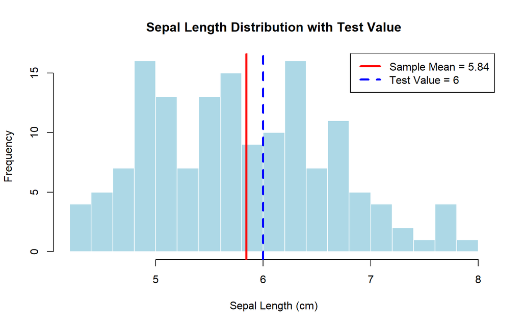

```r
# Visualize
hist(iris$Sepal.Length,
     main = "Sepal Length Distribution with Test Value",
     xlab = "Sepal Length (cm)",
     col = "lightblue",
     border = "white",
     breaks = 15)
abline(v = mean(iris$Sepal.Length), col = "red", lwd = 3, lty = 1)
abline(v = test_value, col = "blue", lwd = 3, lty = 2)
legend("topright",
       legend = c(paste("Sample Mean =", round(mean(iris$Sepal.Length), 2)),
                  paste("Test Value =", test_value)),
       col = c("red", "blue"),
       lty = c(1, 2),
       lwd = 3)
```

### 5.2.3 Example 2: Independent Two-Sample t-test

**Research Question:** Do manual transmission cars have different fuel efficiency than automatic transmission cars?

**Hypotheses:** - H₀: μ_manual = μ_automatic (no difference in mean MPG) - H₁: μ_manual ≠ μ_automatic (means are different) [two-tailed]

```r
# Independent samples t-test
# Compare MPG between automatic and manual transmission

# Prepare data
automatic <- mtcars$mpg[mtcars$am == 0]
manual <- mtcars$mpg[mtcars$am == 1]

cat("=== INDEPENDENT TWO-SAMPLE T-TEST ===\n\n")
```

```
## === INDEPENDENT TWO-SAMPLE T-TEST ===
```

```r
cat("Research Question: Do manual and automatic cars differ in fuel efficiency?\n\n")
```

```
## Research Question: Do manual and automatic cars differ in fuel efficiency?
```

```r
cat("H₀: μ_manual = μ_automatic\n")
```

```
## H₀: μ_manual = μ_automatic
```

```r
cat("H₁: μ_manual ≠ μ_automatic\n\n")
```

```
## H₁: μ_manual ≠ μ_automatic
```

```r
# Perform t-test
result_independent <- t.test(manual, automatic, var.equal = FALSE)

print(result_independent)
```

```
##
##  Welch Two Sample t-test
##
## data:  manual and automatic
## t = 3.7671, df = 18.332, p-value = 0.001374
## alternative hypothesis: true difference in means is not equal to 0
## 95 percent confidence interval:
##   3.209684 11.280194
## sample estimates:
## mean of x mean of y
##  24.39231  17.14737
```

```r
cat("\n=== DESCRIPTIVE STATISTICS ===\n")
```

```
##
## === DESCRIPTIVE STATISTICS ===
```

```r
cat("Automatic transmission:\n")
```

```
## Automatic transmission:
```

```r
cat("  n =", length(automatic), "\n")
```

```
##   n = 19
```

```r
cat("  Mean =", round(mean(automatic), 2), "mpg\n")
```

```
##   Mean = 17.15 mpg
```

```r
cat("  SD =", round(sd(automatic), 2), "\n\n")
```

```
##   SD = 3.83
```

```r
cat("Manual transmission:\n")
```

```
## Manual transmission:
```

```r
cat("  n =", length(manual), "\n")
```

```
##   n = 13
```

```r
cat("  Mean =", round(mean(manual), 2), "mpg\n")
```

```
##   Mean = 24.39 mpg
```

```r
cat("  SD =", round(sd(manual), 2), "\n\n")
```

```
##   SD = 6.17
```

```r
cat("=== INTERPRETATION ===\n")
```

```
## === INTERPRETATION ===
```

```r
cat("Difference in means:", round(mean(manual) - mean(automatic), 2), "mpg\n")
```

```
## Difference in means: 7.24 mpg
```

```r
cat("t-statistic:", round(result_independent$statistic, 3), "\n")
```

```
## t-statistic: 3.767
```

```r
cat("p-value:", format.pval(result_independent$p.value, digits = 4), "\n\n")
```

```
## p-value: 0.001374
```

```r
if(result_independent$p.value < 0.05) {
  cat("Decision: REJECT H₀ (p < 0.05)\n")
  cat("Conclusion: Manual and automatic transmissions have significantly different MPG.\n")
  cat("Manual transmission cars have",
      ifelse(mean(manual) > mean(automatic), "HIGHER", "LOWER"),
      "fuel efficiency.\n")
} else {
  cat("Decision: FAIL TO REJECT H₀ (p ≥ 0.05)\n")
  cat("Conclusion: No significant difference in MPG between transmission types.\n")
}
```

```
## Decision: REJECT H₀ (p < 0.05)
## Conclusion: Manual and automatic transmissions have significantly different MPG.
## Manual transmission cars have HIGHER fuel efficiency.
```

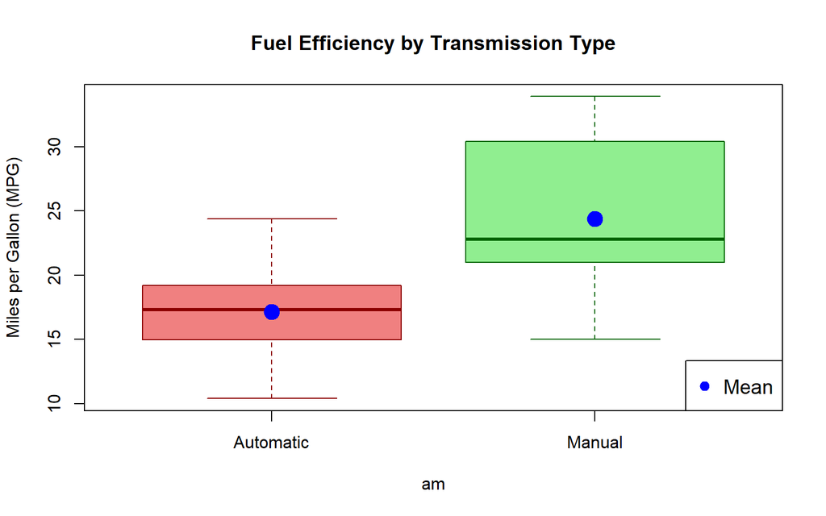

```r
# Visualize
boxplot(mpg ~ am, data = mtcars,
        names = c("Automatic", "Manual"),
        main = "Fuel Efficiency by Transmission Type",
        ylab = "Miles per Gallon (MPG)",
        col = c("lightcoral", "lightgreen"),
        border = c("darkred", "darkgreen"))
points(c(1, 2), c(mean(automatic), mean(manual)),
       pch = 19, col = "blue", cex = 2)
legend("bottomright", legend = "Mean", pch = 19, col = "blue", cex = 1.2)
```

### 5.2.4 Example 3: Paired t-test

**Research Question:** Does a new teaching method improve test scores?

**Hypotheses:** - H₀: μ_difference = 0 (no change in scores) - H₁: μ_difference > 0 (scores increased) [one-tailed]

```r
# Paired t-test
# Create example data: before and after scores
set.seed(seeds[3])

n_students <- 25
before_scores <- rnorm(n_students, mean = 70, sd = 10)
# Add improvement effect
improvement <- rnorm(n_students, mean = 5, sd = 8)
after_scores <- before_scores + improvement

student_data <- data.frame(
  Student = 1:n_students,
  Before = round(before_scores, 1),
  After = round(after_scores, 1),
  Difference = round(after_scores - before_scores, 1)
)

cat("=== PAIRED T-TEST (BEFORE-AFTER DESIGN) ===\n\n")
```

```
## === PAIRED T-TEST (BEFORE-AFTER DESIGN) ===
```

```r
cat("Research Question: Did the new teaching method improve test scores?\n\n")
```

```
## Research Question: Did the new teaching method improve test scores?
```

```r
cat("H₀: μ_difference = 0 (no improvement)\n")
```

```
## H₀: μ_difference = 0 (no improvement)
```

```r
cat("H₁: μ_difference > 0 (scores improved) [one-tailed]\n\n")
```

```
## H₁: μ_difference > 0 (scores improved) [one-tailed]
```

```r
# Show first few students
cat("Sample Data (first 6 students):\n")
```

```
## Sample Data (first 6 students):
```

```r
head(student_data) %>%
  kable() %>%
  kable_styling(bootstrap_options = c("striped", "hover"))
```

| Student | Before | After | Difference |
| --- | --- | --- | --- |
| 1 | 85.0 | 84.3 | -0.7 |
| 2 | 54.8 | 55.0 | 0.2 |
| 3 | 67.6 | 86.9 | 19.3 |
| 4 | 59.0 | 64.8 | 5.8 |
| 5 | 77.2 | 90.9 | 13.7 |
| 6 | 72.7 | 81.5 | 8.9 |

```r
# Perform paired t-test (one-tailed)
result_paired <- t.test(student_data$After, student_data$Before,
                        paired = TRUE,
                        alternative = "greater")

cat("\n")
```

```r
print(result_paired)
```

```
##
##  Paired t-test
##
## data:  student_data$After and student_data$Before
## t = 3.1343, df = 24, p-value = 0.002251
## alternative hypothesis: true mean difference is greater than 0
## 95 percent confidence interval:
##  2.44324     Inf
## sample estimates:
## mean difference
##            5.38
```

```r
cat("\n=== DESCRIPTIVE STATISTICS ===\n")
```

```
##
## === DESCRIPTIVE STATISTICS ===
```

```r
cat("Before: Mean =", round(mean(student_data$Before), 2),
    ", SD =", round(sd(student_data$Before), 2), "\n")
```

```
## Before: Mean = 70.15 , SD = 11.15
```

```r
cat("After:  Mean =", round(mean(student_data$After), 2),
    ", SD =", round(sd(student_data$After), 2), "\n")
```

```
## After:  Mean = 75.53 , SD = 14.87
```

```r
cat("Mean Difference:", round(mean(student_data$Difference), 2), "points\n\n")
```

```
## Mean Difference: 5.38 points
```

```r
cat("=== INTERPRETATION ===\n")
```

```
## === INTERPRETATION ===
```

```r
cat("t-statistic:", round(result_paired$statistic, 3), "\n")
```

```
## t-statistic: 3.134
```

```r
cat("p-value (one-tailed):", format.pval(result_paired$p.value, digits = 4), "\n\n")
```

```
## p-value (one-tailed): 0.002251
```

```r
if(result_paired$p.value < 0.05) {
  cat("Decision: REJECT H₀ (p < 0.05)\n")
  cat("Conclusion: The teaching method significantly improved test scores.\n")
} else {
  cat("Decision: FAIL TO REJECT H₀ (p ≥ 0.05)\n")
  cat("Conclusion: No significant evidence of improvement.\n")
}
```

```
## Decision: REJECT H₀ (p < 0.05)
## Conclusion: The teaching method significantly improved test scores.
```

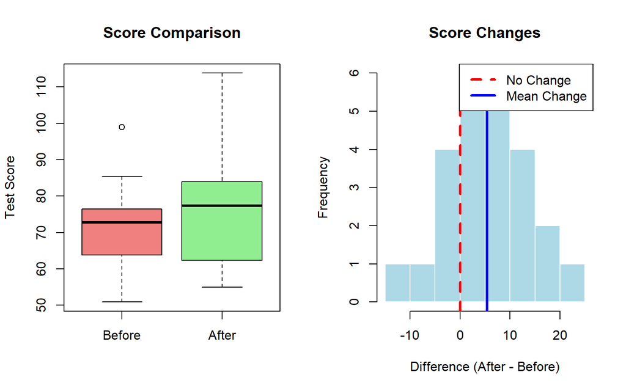

```r
# Visualize
par(mfrow = c(1, 2))

# Box plot comparison
boxplot(student_data$Before, student_data$After,
        names = c("Before", "After"),
        main = "Score Comparison",
        ylab = "Test Score",
        col = c("lightcoral", "lightgreen"))

# Difference histogram
hist(student_data$Difference,
     main = "Score Changes",
     xlab = "Difference (After - Before)",
     col = "lightblue",
     border = "white")
abline(v = 0, col = "red", lwd = 3, lty = 2)
abline(v = mean(student_data$Difference), col = "blue", lwd = 3)
legend("topright",
       legend = c("No Change", "Mean Change"),
       col = c("red", "blue"),
       lty = c(2, 1),
       lwd = 3)
```

```r
par(mfrow = c(1, 1))
```

## 5.3 Other Common Tests

### 5.3.1 Chi-Square Test (Categorical Data)

**Research Question:** Is there a relationship between transmission type and number of cylinders?

```r
# Chi-square test for independence
cat("=== CHI-SQUARE TEST OF INDEPENDENCE ===\n\n")
```

```
## === CHI-SQUARE TEST OF INDEPENDENCE ===
```

```r
cat("Research Question: Are transmission type and cylinder count independent?\n\n")
```

```
## Research Question: Are transmission type and cylinder count independent?
```

```r
cat("H₀: Transmission and cylinders are independent (no relationship)\n")
```

```
## H₀: Transmission and cylinders are independent (no relationship)
```

```r
cat("H₁: Transmission and cylinders are related\n\n")
```

```
## H₁: Transmission and cylinders are related
```

```r
# Create contingency table
contingency_table <- table(mtcars$am, mtcars$cyl)
rownames(contingency_table) <- c("Automatic", "Manual")
colnames(contingency_table) <- paste(c(4, 6, 8), "cyl")

cat("Contingency Table:\n")
```

```
## Contingency Table:
```

```r
print(contingency_table)
```

```
##
##             4 cyl 6 cyl 8 cyl
##   Automatic     3     4    12
##   Manual        8     3     2
```

```r
# Perform chi-square test
result_chisq <- chisq.test(contingency_table)
cat("\n")
```

```r
print(result_chisq)
```

```
##
##  Pearson's Chi-squared test
##
## data:  contingency_table
## X-squared = 8.7407, df = 2, p-value = 0.01265
```

```r
cat("\n=== INTERPRETATION ===\n")
```

```
##
## === INTERPRETATION ===
```

```r
cat("Chi-square statistic:", round(result_chisq$statistic, 3), "\n")
```

```
## Chi-square statistic: 8.741
```

```r
cat("p-value:", format.pval(result_chisq$p.value, digits = 4), "\n\n")
```

```
## p-value: 0.01265
```

```r
if(result_chisq$p.value < 0.05) {
  cat("Decision: REJECT H₀ (p < 0.05)\n")
  cat("Conclusion: There is a significant relationship between transmission and cylinders.\n")
} else {
  cat("Decision: FAIL TO REJECT H₀ (p ≥ 0.05)\n")
  cat("Conclusion: No significant relationship detected.\n")
}
```

```
## Decision: REJECT H₀ (p < 0.05)
## Conclusion: There is a significant relationship between transmission and cylinders.
```

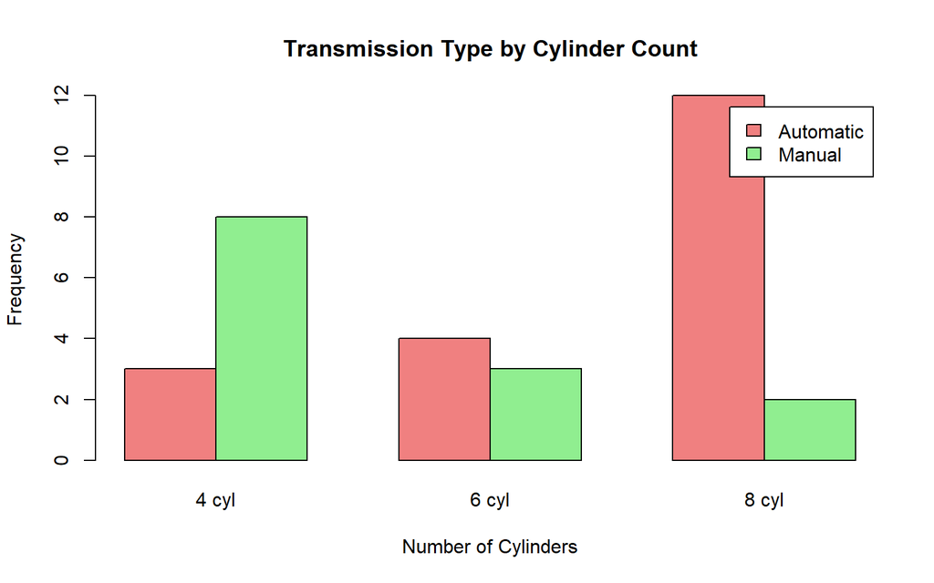

```r
# Visualize
barplot(contingency_table,
        beside = TRUE,
        legend = TRUE,
        main = "Transmission Type by Cylinder Count",
        xlab = "Number of Cylinders",
        ylab = "Frequency",
        col = c("lightcoral", "lightgreen"))
```

### 5.3.2 Correlation Test

**Research Question:** Is there a linear relationship between car weight and fuel efficiency?

```r
# Correlation test
cat("=== CORRELATION TEST ===\n\n")
```

```
## === CORRELATION TEST ===
```

```r
cat("Research Question: Is there a correlation between weight and MPG?\n\n")
```

```
## Research Question: Is there a correlation between weight and MPG?
```

```r
cat("H₀: ρ = 0 (no correlation)\n")
```

```
## H₀: ρ = 0 (no correlation)
```

```r
cat("H₁: ρ ≠ 0 (correlation exists)\n\n")
```

```
## H₁: ρ ≠ 0 (correlation exists)
```

```r
# Perform correlation test
result_cor <- cor.test(mtcars$wt, mtcars$mpg)

print(result_cor)
```

```
##
##  Pearson's product-moment correlation
##
## data:  mtcars$wt and mtcars$mpg
## t = -9.559, df = 30, p-value = 1.294e-10
## alternative hypothesis: true correlation is not equal to 0
## 95 percent confidence interval:
##  -0.9338264 -0.7440872
## sample estimates:
##        cor
## -0.8676594
```

```r
cat("\n=== INTERPRETATION ===\n")
```

```
##
## === INTERPRETATION ===
```

```r
cat("Correlation coefficient (r):", round(result_cor$estimate, 3), "\n")
```

```
## Correlation coefficient (r): -0.868
```

```r
cat("t-statistic:", round(result_cor$statistic, 3), "\n")
```

```
## t-statistic: -9.559
```

```r
cat("p-value:", format.pval(result_cor$p.value, digits = 4), "\n\n")
```

```
## p-value: 1.294e-10
```

```r
if(result_cor$p.value < 0.05) {
  cat("Decision: REJECT H₀ (p < 0.05)\n")
  cat("Conclusion: There is a significant",
      ifelse(result_cor$estimate < 0, "NEGATIVE", "POSITIVE"),
      "correlation.\n")
  cat("Interpretation:", abs(round(result_cor$estimate, 3)),
      "indicates a",
      ifelse(abs(result_cor$estimate) > 0.7, "strong",
             ifelse(abs(result_cor$estimate) > 0.4, "moderate", "weak")),
      "relationship.\n")
} else {
  cat("Decision: FAIL TO REJECT H₀ (p ≥ 0.05)\n")
  cat("Conclusion: No significant correlation detected.\n")
}
```

```
## Decision: REJECT H₀ (p < 0.05)
## Conclusion: There is a significant NEGATIVE correlation.
## Interpretation: 0.868 indicates a strong relationship.
```

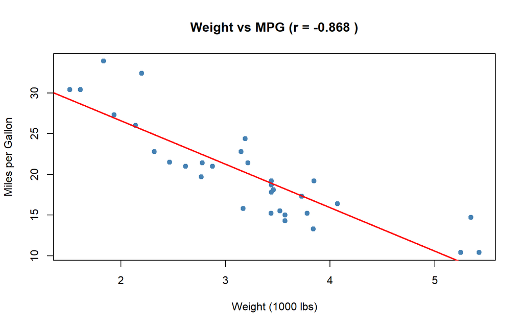

```r
# Visualize
plot(mtcars$wt, mtcars$mpg,
     main = paste("Weight vs MPG (r =", round(result_cor$estimate, 3), ")"),
     xlab = "Weight (1000 lbs)",
     ylab = "Miles per Gallon",
     pch = 19,
     col = "steelblue")
abline(lm(mpg ~ wt, data = mtcars), col = "red", lwd = 2)
```

## 5.4 Effect Size and Power

### 5.4.1 Understanding Effect Size

**Effect size** measures the magnitude of a difference or relationship, independent of sample size.

**Common Effect Size Measures:** - **Cohen’s d**: For t-tests (small: 0.2, medium: 0.5, large: 0.8) - **r**: For correlations (small: 0.1, medium: 0.3, large: 0.5) - **η² (eta-squared)**: For ANOVA

```r
# Calculate Cohen's d for transmission comparison
# Install effsize if needed
if (!require("effsize", quietly = TRUE)) {
  install.packages("effsize", repos = "https://cran.r-project.org")
  library(effsize)
}

cat("=== EFFECT SIZE ANALYSIS ===\n\n")
```

```
## === EFFECT SIZE ANALYSIS ===
```

```r
# Cohen's d for transmission effect on MPG
cohens_d <- cohen.d(mtcars$mpg ~ factor(mtcars$am))
print(cohens_d)
```

```
##
## Cohen's d
##
## d estimate: -1.477947 (large)
## 95 percent confidence interval:
##     lower     upper
## -2.304209 -0.651685
```

```r
cat("\n=== INTERPRETATION ===\n")
```

```
##
## === INTERPRETATION ===
```

```r
cat("Cohen's d:", round(cohens_d$estimate, 3), "\n")
```

```
## Cohen's d: -1.478
```

```r
cat("Magnitude:", cohens_d$magnitude, "\n\n")
```

```
## Magnitude: 4
```

```r
cat("Effect Size Guidelines (Cohen, 1988):\n")
```

```
## Effect Size Guidelines (Cohen, 1988):
```

```r
cat("  Small:  d = 0.2\n")
```

```
##   Small:  d = 0.2
```

```r
cat("  Medium: d = 0.5\n")
```

```
##   Medium: d = 0.5
```

```r
cat("  Large:  d = 0.8\n\n")
```

```
##   Large:  d = 0.8
```

```r
cat("Practical Significance:\n")
```

```
## Practical Significance:
```

```r
if(abs(cohens_d$estimate) < 0.2) {
  cat("The effect is negligible - may not be practically important.\n")
} else if(abs(cohens_d$estimate) < 0.5) {
  cat("The effect is small - some practical importance.\n")
} else if(abs(cohens_d$estimate) < 0.8) {
  cat("The effect is medium - likely practically important.\n")
} else {
  cat("The effect is large - very practically important.\n")
}
```

```
## The effect is large - very practically important.
```

## 5.5 Summary of Hypothesis Testing

Common Hypothesis Tests in R

| Test | Purpose | Data_Type | R_Function |
| --- | --- | --- | --- |
| One-Sample t-test | Compare sample mean to known value | Continuous | t.test(x, mu=value) |
| Independent t-test | Compare means of two independent groups | Continuous | t.test(x, y) |
| Paired t-test | Compare means of paired/related observations | Continuous | t.test(x, y, paired=TRUE) |
| Chi-Square Test | Test relationship between categorical variables | Categorical | chisq.test(table) |
| Correlation Test | Test linear relationship between continuous variables | Continuous | cor.test(x, y) |
| ANOVA | Compare means of 3+ groups | Continuous | aov() or anova() |

### 5.5.1 Key Reminders

1. **Always state your hypotheses** before looking at the data
2. **Check assumptions** before running tests (normality, equal variances, etc.)
3. **Report effect sizes** alongside p-values
4. **Consider practical significance** not just statistical significance
5. **Be cautious with multiple testing** - adjust α if doing many tests
6. **Never say “prove”** - we reject or fail to reject H₀

# Part 6: Practical Applications

## 6.1 Case Study 1: Air Quality Analysis

```r
# Load and explore air quality data
data(airquality)

cat("=== AIR QUALITY DATASET ===\n")
```

```
## === AIR QUALITY DATASET ===
```

```r
cat("Dimensions:", dim(airquality), "\n")
```

```
## Dimensions: 153 6
```

```r
cat("Variables:", names(airquality), "\n\n")
```

```
## Variables: Ozone Solar.R Wind Temp Month Day
```

```r
# Summary statistics
airquality %>%
  summary()
```

```
##      Ozone           Solar.R           Wind             Temp
##  Min.   :  1.00   Min.   :  7.0   Min.   : 1.700   Min.   :56.00
##  1st Qu.: 18.00   1st Qu.:115.8   1st Qu.: 7.400   1st Qu.:72.00
##  Median : 31.50   Median :205.0   Median : 9.700   Median :79.00
##  Mean   : 42.13   Mean   :185.9   Mean   : 9.958   Mean   :77.88
##  3rd Qu.: 63.25   3rd Qu.:258.8   3rd Qu.:11.500   3rd Qu.:85.00
##  Max.   :168.00   Max.   :334.0   Max.   :20.700   Max.   :97.00
##  NA's   :37       NA's   :7
##      Month            Day
##  Min.   :5.000   Min.   : 1.0
##  1st Qu.:6.000   1st Qu.: 8.0
##  Median :7.000   Median :16.0
##  Mean   :6.993   Mean   :15.8
##  3rd Qu.:8.000   3rd Qu.:23.0
##  Max.   :9.000   Max.   :31.0
##
```

```r
# Handle missing values
cat("\nMissing values by variable:\n")
```

```
##
## Missing values by variable:
```

```r
colSums(is.na(airquality))
```

```
##   Ozone Solar.R    Wind    Temp   Month     Day
##      37       7       0       0       0       0
```

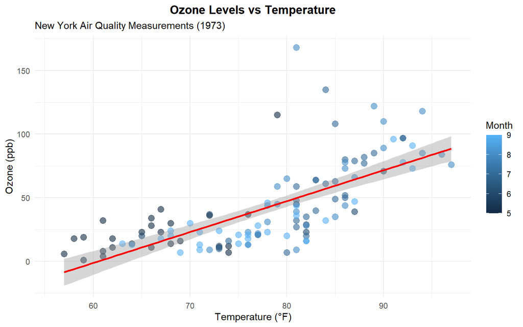

```r
# Visualize relationships
ggplot(airquality, aes(x = Temp, y = Ozone)) +
  geom_point(aes(color = Month), alpha = 0.6, size = 3) +
  geom_smooth(method = "lm", se = TRUE, color = "red") +
  labs(
    title = "Ozone Levels vs Temperature",
    subtitle = "New York Air Quality Measurements (1973)",
    x = "Temperature (°F)",
    y = "Ozone (ppb)"
  ) +
  theme_minimal() +
  theme(plot.title = element_text(hjust = 0.5, face = "bold"))
```

## 6.2 Case Study 2: Motor Trends Analysis

```r
# Motor cars dataset
data(mtcars)

cat("=== MOTOR TRENDS ANALYSIS ===\n\n")
```

```
## === MOTOR TRENDS ANALYSIS ===
```

```r
# Descriptive statistics by transmission type
mtcars_summary <- mtcars %>%
  mutate(Transmission = factor(am, labels = c("Automatic", "Manual"))) %>%
  group_by(Transmission) %>%
  summarise(
    N = n(),
    Mean_MPG = mean(mpg),
    SD_MPG = sd(mpg),
    Mean_HP = mean(hp),
    SD_HP = sd(hp),
    Mean_Weight = mean(wt)
  ) %>%
  mutate(across(where(is.numeric), ~round(., 2)))

mtcars_summary %>%
  kable(caption = "Car Performance by Transmission Type") %>%
  kable_styling(bootstrap_options = c("striped", "hover"))
```

Car Performance by Transmission Type

| Transmission | N | Mean_MPG | SD_MPG | Mean_HP | SD_HP | Mean_Weight |
| --- | --- | --- | --- | --- | --- | --- |
| Automatic | 19 | 17.15 | 3.83 | 160.26 | 53.91 | 3.77 |
| Manual | 13 | 24.39 | 6.17 | 126.85 | 84.06 | 2.41 |

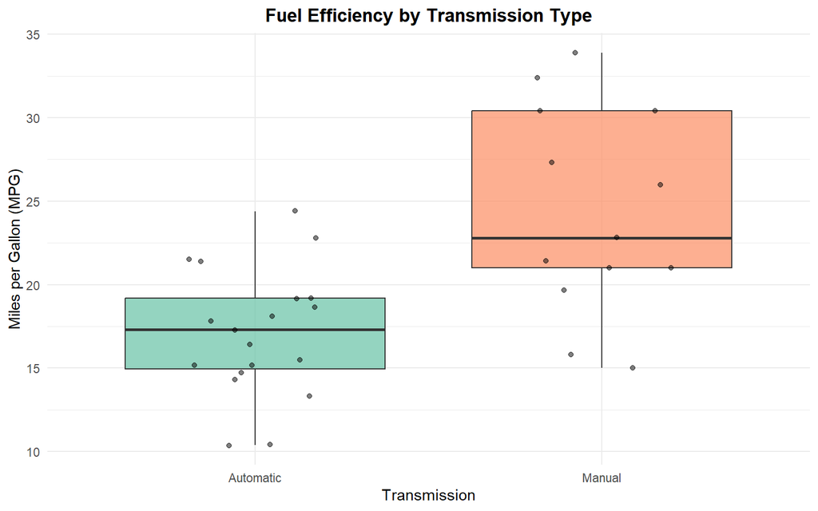

```r
# Visualize MPG distribution
ggplot(mtcars, aes(x = factor(am, labels = c("Automatic", "Manual")), y = mpg)) +
  geom_boxplot(aes(fill = factor(am)), alpha = 0.7) +
  geom_jitter(width = 0.2, alpha = 0.5) +
  labs(
    title = "Fuel Efficiency by Transmission Type",
    x = "Transmission",
    y = "Miles per Gallon (MPG)"
  ) +
  theme_minimal() +
  theme(
    plot.title = element_text(hjust = 0.5, face = "bold"),
    legend.position = "none"
  ) +
  scale_fill_brewer(palette = "Set2")
```

## 6.3 Case Study 3: Population vs Sample

```r
# Demonstrate population vs sample concepts
# Use seedhash for reproducible sampling
set.seed(seeds[2])  # Use second seed from our generator

# Population: All iris flowers
population_mean <- mean(iris$Sepal.Length)
population_sd <- sd(iris$Sepal.Length)

cat("=== POPULATION STATISTICS ===\n")
```

```
## === POPULATION STATISTICS ===
```

```r
cat("Population Size:", nrow(iris), "\n")
```

```
## Population Size: 150
```

```r
cat("Population Mean:", round(population_mean, 3), "\n")
```

```
## Population Mean: 5.843
```

```r
cat("Population SD:", round(population_sd, 3), "\n\n")
```

```
## Population SD: 0.828
```

```r
# Take multiple samples
sample_sizes <- c(10, 30, 50)
sample_results <- list()

for(n in sample_sizes) {
  sample_means <- replicate(1000, mean(sample(iris$Sepal.Length, n)))
  sample_results[[as.character(n)]] <- data.frame(
    Sample_Size = n,
    Mean_of_Means = mean(sample_means),
    SD_of_Means = sd(sample_means),
    Min = min(sample_means),
    Max = max(sample_means)
  )
}

sample_comparison <- bind_rows(sample_results) %>%
  mutate(across(where(is.numeric) & !Sample_Size, ~round(., 4)))

cat("=== SAMPLING DISTRIBUTION ===\n")
```

```
## === SAMPLING DISTRIBUTION ===
```

```r
cat("Based on 1000 samples for each size\n\n")
```

```
## Based on 1000 samples for each size
```

```r
sample_comparison %>%
  kable(caption = "Effect of Sample Size on Sampling Distribution") %>%
  kable_styling(bootstrap_options = c("striped", "hover"))
```

Effect of Sample Size on Sampling Distribution

| Sample_Size | Mean_of_Means | SD_of_Means | Min | Max |
| --- | --- | --- | --- | --- |
| 10 | 5.8449 | 0.2560 | 4.9900 | 6.710 |
| 30 | 5.8446 | 0.1337 | 5.4267 | 6.320 |
| 50 | 5.8371 | 0.0930 | 5.5200 | 6.112 |

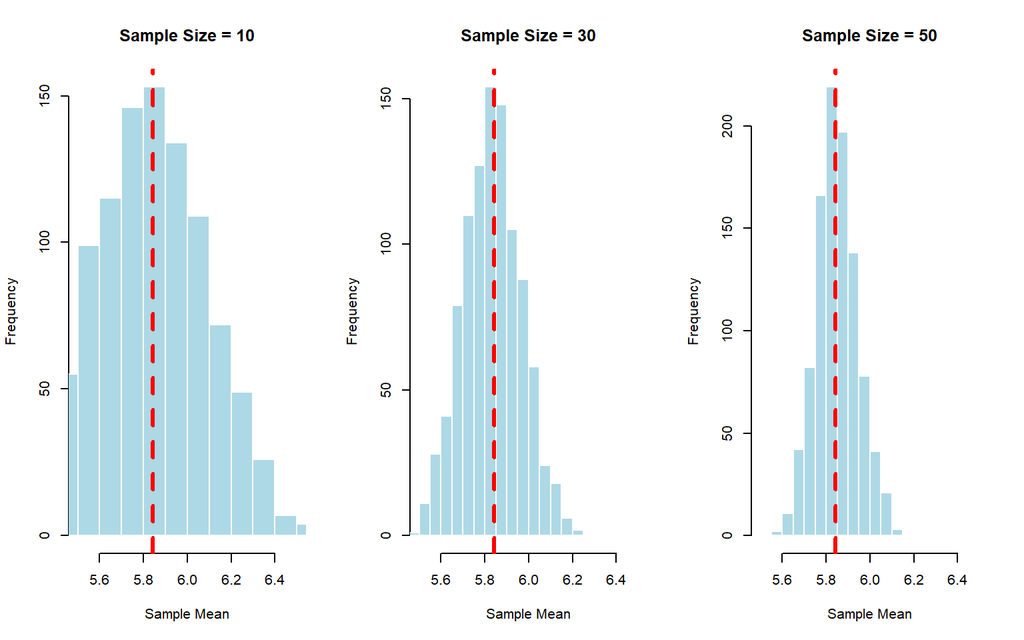

```r
# Visualize sampling distributions
par(mfrow = c(1, 3))
for(n in sample_sizes) {
  sample_means <- replicate(1000, mean(sample(iris$Sepal.Length, n)))
  hist(sample_means,
       main = paste("Sample Size =", n),
       xlab = "Sample Mean",
       col = "lightblue",
       border = "white",
       xlim = c(5.5, 6.5))
  abline(v = population_mean, col = "red", lwd = 3, lty = 2)
}
```

```r
par(mfrow = c(1, 1))
```

# Part 7: Summary and Best Practices

## 7.1 Key Takeaways

### 1. Data Types Matter

- **Categorical**: Nominal, Ordinal, Binary
- **Continuous**: Interval, Ratio
- Choose appropriate statistics and visualizations for each type

### 2. Descriptive Statistics

**Central Tendency:** - Mean: Average (sensitive to outliers) - Median: Middle value (robust to outliers) - Mode: Most frequent value

**Dispersion:** - Range: Max - Min (sensitive to extremes) - IQR: Q3 - Q1 (robust measure) - Standard Deviation: Average deviation from mean

### 3. Visualization Principles

- Always visualize your data before analysis
- Use appropriate plot types for your data
- Check for outliers and unusual patterns
- Verify assumptions (normality, linearity, etc.)

### 4. Statistical Modeling

- Start simple, add complexity as needed
- Check model assumptions and diagnostics
- Compare model performance metrics
- Validate predictions on new data

## 7.2 R Code Cheat Sheet

```r
# ===== DATA EXPLORATION =====
# Load data
data(dataset_name)
head(df)              # First 6 rows
tail(df)              # Last 6 rows
str(df)               # Structure
summary(df)           # Summary statistics
dim(df)               # Dimensions
names(df)             # Variable names

# ===== DESCRIPTIVE STATISTICS =====
mean(x)               # Mean
median(x)             # Median
sd(x)                 # Standard deviation
var(x)                # Variance
range(x)              # Range
IQR(x)                # Interquartile range
quantile(x)           # Quartiles
table(x)              # Frequency table

# ===== VISUALIZATION =====
hist(x)               # Histogram
boxplot(x)            # Boxplot
plot(x, y)            # Scatterplot
barplot(table(x))     # Bar plot
pairs(df)             # Scatterplot matrix

# ===== TIDYVERSE =====
df %>%
  filter(condition) %>%       # Filter rows
  select(var1, var2) %>%      # Select columns
  mutate(new_var = ...) %>%   # Create new variables
  group_by(category) %>%      # Group data
  summarise(mean = mean(x))   # Summarize

# ===== MODELING =====
model <- lm(y ~ x, data = df)     # Linear regression
summary(model)                     # Model summary
predict(model, newdata = new_df)  # Predictions
plot(model)                        # Diagnostic plots

# ===== TESTING =====
t.test(x, y)          # T-test
cor.test(x, y)        # Correlation test
chisq.test(x, y)      # Chi-square test
shapiro.test(x)       # Normality test
```

## 7.3 Common Mistakes to Avoid

```r
# ❌ BAD: Not checking for missing values
mean(data$variable)

# ✅ GOOD: Handle missing values
mean(data$variable, na.rm = TRUE)

# ❌ BAD: Assuming normality without checking
t.test(group1, group2)

# ✅ GOOD: Check normality first
shapiro.test(group1)
hist(group1)
# Then decide on appropriate test

# ❌ BAD: Not setting seed for reproducibility
sample(data, 10)

# ✅ GOOD: Set seed for reproducible results
set.seed(123)
sample(data, 10)

# ✅ BEST: Use seedhash for reproducible, named seeds
library(seedhash)
gen <- SeedHashGenerator$new("YourName")
seeds <- gen$generate_seeds(5)
set.seed(seeds[1])
sample(data, 10)

# ❌ BAD: Ignoring assumptions
model <- lm(y ~ x)
# Use model without checking

# ✅ GOOD: Check assumptions
model <- lm(y ~ x)
plot(model)  # Check diagnostic plots
```

## 7.4 Additional Resources

### 7.4.1 Recommended Packages

```r
# Data Manipulation
install.packages("dplyr")        # Data wrangling
install.packages("tidyr")        # Data tidying
install.packages("data.table")   # Fast data manipulation

# Visualization
install.packages("ggplot2")      # Advanced plotting
install.packages("plotly")       # Interactive plots
install.packages("ggpubr")       # Publication-ready plots

# Statistics
install.packages("moments")      # Skewness & kurtosis
install.packages("car")          # Regression diagnostics
install.packages("psych")        # Psychological statistics

# Reproducibility
install.packages("seedhash")     # Reproducible seed generation

# Tables
install.packages("knitr")        # Basic tables
install.packages("kableExtra")   # Enhanced tables
install.packages("gt")           # Grammar of tables
```

### 7.4.2 Learning Resources

- **R Documentation**: `?function_name` or `help(function_name)`
- **RStudio Cheatsheets**: https://www.rstudio.com/resources/cheatsheets/
- **R for Data Science**: https://r4ds.had.co.nz/
- **Quick-R**: https://www.statmethods.net/
- **Stack Overflow**: https://stackoverflow.com/questions/tagged/r

### 7.4.3 Getting Help

```r
# View function documentation
?mean
help(lm)

# Search for functions
??regression

# View examples
example(plot)

# Check package vignettes
browseVignettes("dplyr")
```

# Practice Exercises

## Exercise 1: Descriptive Statistics

Using the `mtcars` dataset:

1. Calculate mean, median, and standard deviation of `mpg`
2. Create a frequency table of `cyl` (number of cylinders)
3. Calculate the IQR of `hp` (horsepower)
4. Identify any outliers in `wt` (weight)

```r
# Your code here
```

## Exercise 2: Visualization

1. Create a histogram of `mpg` with appropriate labels
2. Make a boxplot comparing `mpg` across different `cyl` values
3. Create a scatterplot of `wt` vs `mpg` with a regression line

```r
# Your code here
```

## Exercise 3: Simple Analysis

1. Test if there’s a relationship between `hp` and `mpg`
2. Build a linear model predicting `mpg` from `wt`
3. Interpret the model coefficients and R-squared value

```r
# Your code here
```

**End of Week 02: R for Data Analytics Tutorial**

*ANLY 500 - Analytics I*

*Harrisburg University*